# xBD_fine_tuning

## Deep Learning Final Project

Mark Deng · Jun Luu · Sam Sen

### Problem Definition & Technical Justification

This project addresses building-level post-disaster damage classification for a local study area affected by Hurricane Ian. The target users are local emergency managers, planners, and government recovery teams who need a rapid way to identify damaged buildings after a disaster. The final output is a per-building damage prediction, first on a labeled test set and then across the full building footprint layer, using three local classes: no damage, damaged, and destroyed.

Technically, the model learns visual patterns associated with building condition from cropped pre-event and post-event image chips centered on each building footprint. This approach is appropriate because damage is expressed both in post-event appearance and in the change between pre- and post-event imagery, while the available local labeled dataset is relatively small. Using a pre-trained xBD baseline and then fine-tuning it on local labels allows the model to reuse transferable disaster-imagery features while adapting to local building types and local label definitions. Anticipated failure modes included confusion between no damage and moderate damage, imperfect localization caused by dense neighboring buildings, and limited generalization from a small labeled sample. In practice, these issues appeared most clearly in the low recall for label 0 and the stronger performance on damage-related labels. To address them, the workflow used building-level square crops with a small context buffer, explicit baseline comparisons, and a staged fine-tuning strategy that froze the deep backbone while adapting shallower and task-specific layers.

### Methodological Precedent

Three sources most directly shaped the modeling strategy used in this notebook. First, the xBD dataset and baseline model (Gupta et al., 2019) provided both the pretrained starting point and the architectural reference for disaster damage classification from remote sensing imagery. Second, work on Siamese and shared-encoder networks for change detection (e.g., Daudt et al., 2018) motivated the bi-temporal design of Model 4, which combines pre-event features, post-event features, and their absolute difference. Third, prior work on transfer learning for disaster imagery with limited local labels informed the decision to freeze the deeper ResNet backbone and fine-tune only the more adaptable shallow and head layers. Together, these precedents justified a workflow that balances methodological grounding, limited local data, and practical deployment needs.

```python
from google.colab import drive
drive.mount('/content/drive')
```

### 0. EDA on our study area and labeled data

#### 0.1 Study Area and Period

```python
import numpy as np
import rasterio
from shapely.geometry import box
from shapely.geometry import box
import matplotlib.pyplot as plt
import geopandas as gpd
```

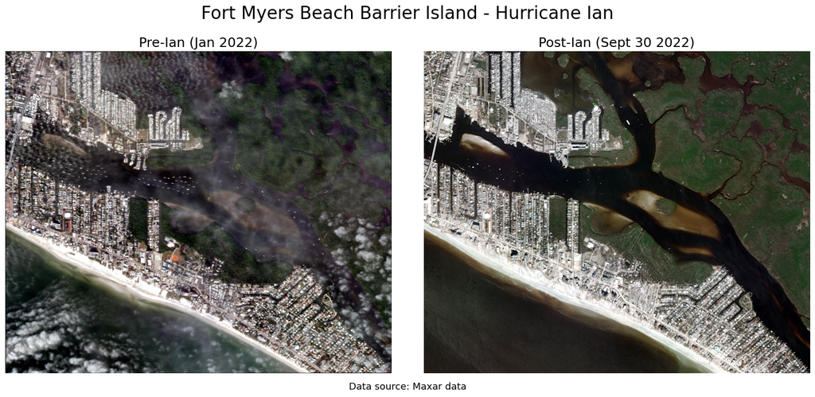

```python
## study area

def read_rgb_tif(path, bands=(1, 2, 3)):
    """
    Read selected bands from a GeoTIFF and return as H x W x C array.
    bands uses 1-based indexing as in rasterio.
    """
    with rasterio.open(path) as src:
        arr = src.read(list(bands))  # shape: (bands, rows, cols)
    return np.transpose(arr, (1, 2, 0))  # -> (rows, cols, bands)


def percentile_stretch(img, lower=2, upper=98):
    """
    Simple percentile stretch for visualization.
    Works band-by-band and returns float image in [0, 1].
    """
    img = img.astype(np.float32)
    out = np.zeros_like(img, dtype=np.float32)

    for i in range(img.shape[2]):
        band = img[:, :, i]
        lo = np.percentile(band, lower)
        hi = np.percentile(band, upper)

        if hi <= lo:
            out[:, :, i] = 0
        else:
            out[:, :, i] = np.clip((band - lo) / (hi - lo), 0, 1)

    return out


# === paths ===
pre_path = "/content/drive/MyDrive/data/pre-lan-full.tif"
post_path = "/content/drive/MyDrive/data/post-lan-full.tif"

# === read images ===
pre_img = read_rgb_tif(pre_path, bands=(1, 2, 3))
post_img = read_rgb_tif(post_path, bands=(1, 2, 3))

# === stretch for display ===
pre_vis = percentile_stretch(pre_img)
post_vis = percentile_stretch(post_img)

# === plot ===
fig, axes = plt.subplots(1, 2, figsize=(16, 8))

axes[0].imshow(pre_vis)
axes[0].set_title("Pre-Ian (Jan 2022)", fontsize=18)
axes[0].axis("off")

axes[1].imshow(post_vis)
axes[1].set_title("Post-Ian (Sept 30 2022)", fontsize=18)
axes[1].axis("off")

fig.suptitle("Fort Myers Beach Barrier Island - Hurricane Ian", fontsize=24, y=0.95)
fig.text(0.5, 0.04, "Data source: Maxar data", ha="center", fontsize=13)

plt.tight_layout(rect=[0, 0.06, 1, 0.92])
plt.show()
```

#### 0.2 Labels

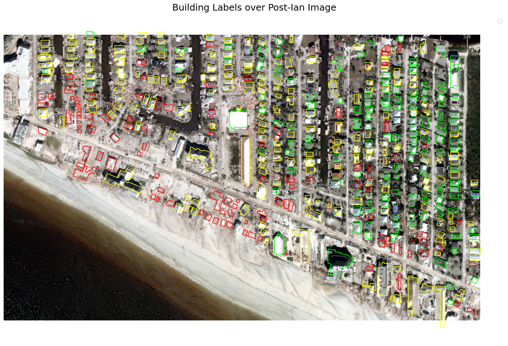

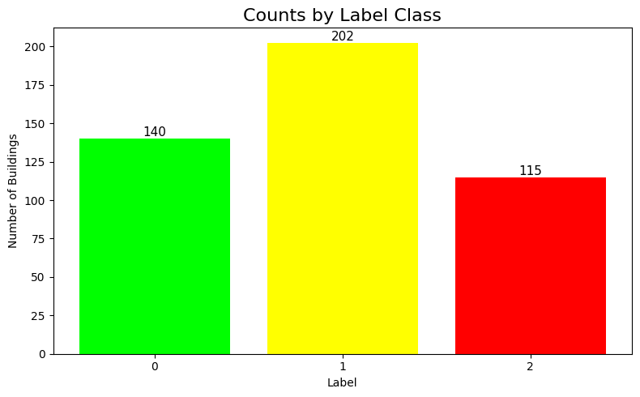

```python
def read_rgb_tif(path, bands=(1, 2, 3)):
    """
    Read selected bands from GeoTIFF and return H x W x C array.
    """
    with rasterio.open(path) as src:
        arr = src.read(list(bands))   # (bands, rows, cols)
    return np.transpose(arr, (1, 2, 0))  # -> (rows, cols, bands)


def percentile_stretch(img, lower=2, upper=98):
    """
    Stretch image band-by-band to [0, 1] for nicer visualization.
    """
    img = img.astype(np.float32)
    out = np.zeros_like(img, dtype=np.float32)

    for i in range(img.shape[2]):
        band = img[:, :, i]
        lo = np.percentile(band, lower)
        hi = np.percentile(band, upper)

        if hi <= lo:
            out[:, :, i] = 0
        else:
            out[:, :, i] = np.clip((band - lo) / (hi - lo), 0, 1)

    return out


# =========================
# paths
# =========================
shp_path = "/content/drive/MyDrive/data/label.shp"
raster_path = "/content/drive/MyDrive/data/post-lan-label.tif"

# =========================
# read data
# =========================
gdf = gpd.read_file(shp_path)

with rasterio.open(raster_path) as src:
    raster_crs = src.crs
    raster_bounds = src.bounds

post_img = read_rgb_tif(raster_path, bands=(1, 2, 3))
post_vis = percentile_stretch(post_img)

# =========================
# clean / filter labels
# =========================
# keep only classes 0, 1, 2; remove 99 and anything else
gdf = gdf[gdf["label"].isin([0, 1, 2])].copy()

# reproject shp to raster CRS if needed
if gdf.crs != raster_crs:
    gdf = gdf.to_crs(raster_crs)

# color map for classes
class_colors = {
    0: "lime",       # no / low damage
    1: "yellow",     # moderate
    2: "red"         # high damage
}

# =========================
# map visualization
# =========================
fig, ax = plt.subplots(figsize=(14, 14))

# show raster
ax.imshow(
    post_vis,
    extent=[raster_bounds.left, raster_bounds.right, raster_bounds.bottom, raster_bounds.top],
    origin="upper"
)

# overlay polygon outlines by class
for cls in [0, 1, 2]:
    subset = gdf[gdf["label"] == cls]
    if len(subset) > 0:
        subset.plot(
            ax=ax,
            facecolor="none",          # transparent fill
            edgecolor=class_colors[cls],
            linewidth=1.2,
            label=f"Label {cls}"
        )

ax.set_title("Building Labels over Post-Ian Image", fontsize=18, pad=12)
ax.legend()
ax.set_axis_off()
plt.tight_layout()
plt.show()

# =========================
# bar chart for class counts
# =========================
counts = gdf["label"].value_counts().reindex([0, 1, 2], fill_value=0)

fig, ax = plt.subplots(figsize=(8, 5))
ax.bar(
    counts.index.astype(str),
    counts.values,
    color=[class_colors[0], class_colors[1], class_colors[2]]
)

ax.set_title("Counts by Label Class", fontsize=16)
ax.set_xlabel("Label")
ax.set_ylabel("Number of Buildings")

# add value labels on top
for i, v in enumerate(counts.values):
    ax.text(i, v, str(v), ha="center", va="bottom", fontsize=11)

plt.tight_layout()
plt.show()
```

#### 0.3 Data Processing

```python
import pandas as pd
from rasterio.windows import from_bounds
from rasterio.enums import Resampling

LABEL_PATH = "/content/drive/MyDrive/data/label.shp"
PRE_PATH = "/content/drive/MyDrive/data/pre-lan-full.tif"
POST_PATH = "/content/drive/MyDrive/data/post-lan-full.tif"

LABEL_COL = "label"
ID_COL = "train_id"
IGNORE_LABEL = 99

BUFFER_PCT = 0.20
TARGET_SIZE = (128, 128)


def make_square_bounds(geom, buffer_pct=0.20):
    """
    Turn one building polygon into its minimum enclosing square bbox,
    then expand it by buffer_pct on each side.
    """
    minx, miny, maxx, maxy = geom.bounds
    width = maxx - minx
    height = maxy - miny
    side_raw = max(width, height)
    side_raw = max(side_raw, 1e-6)  # guard against degenerate polygons

    cx = (minx + maxx) / 2.0
    cy = (miny + maxy) / 2.0

    side_buffered = side_raw * (1 + 2 * buffer_pct)
    half = side_buffered / 2.0

    square_bounds = (cx - half, cy - half, cx + half, cy + half)
    return square_bounds, side_raw, side_buffered


def crop_resize_rgb(src, bounds, target_size=(128, 128)):
    """
    Crop an RGB patch from map bounds and resample it directly to 128 x 128.
    Output shape is (H, W, 3).
    """
    left, bottom, right, top = bounds
    window = from_bounds(left, bottom, right, top, transform=src.transform)

    chip = src.read(
        indexes=[1, 2, 3],
        window=window,
        out_shape=(3, target_size[0], target_size[1]),
        resampling=Resampling.bilinear,
        boundless=True,
        fill_value=0,
    )
    return np.moveaxis(chip, 0, -1)


def build_bitemporal_dataset(
    label_path,
    pre_path,
    post_path,
    label_col="label",
    id_col="train_id",
    ignore_label=99,
    buffer_pct=0.20,
    target_size=(128, 128),
):
    labels_gdf = gpd.read_file(label_path)
    labels_gdf = labels_gdf[labels_gdf[label_col] != ignore_label].copy()
    labels_gdf[label_col] = labels_gdf[label_col].astype(int)

    with rasterio.open(pre_path) as pre_src, rasterio.open(post_path) as post_src:
        if pre_src.crs != post_src.crs:
            raise ValueError("Pre- and post-event rasters must use the same CRS.")

        labels_gdf = labels_gdf.to_crs(post_src.crs)

        metadata_records = []
        pre_chip_list = []
        post_chip_list = []

        for sample_idx, (_, row) in enumerate(labels_gdf.iterrows()):
            square_bounds, side_raw, side_buffered = make_square_bounds(
                row.geometry,
                buffer_pct=buffer_pct,
            )

            pre_chip = crop_resize_rgb(pre_src, square_bounds, target_size=target_size)
            post_chip = crop_resize_rgb(post_src, square_bounds, target_size=target_size)

            pre_chip_list.append(pre_chip)
            post_chip_list.append(post_chip)

            metadata_records.append({
                "sample_id": sample_idx,
                "train_id": row[id_col],
                "label": int(row[label_col]),
                "xmin": square_bounds[0],
                "ymin": square_bounds[1],
                "xmax": square_bounds[2],
                "ymax": square_bounds[3],
                "square_side_raw": side_raw,
                "square_side_buffered": side_buffered,
            })

    metadata_df = pd.DataFrame(metadata_records)
    pre_chips = np.asarray(pre_chip_list, dtype=np.uint8)
    post_chips = np.asarray(post_chip_list, dtype=np.uint8)
    y = metadata_df["label"].to_numpy(dtype=np.int32)

    # Keep metadata readable and tensors aligned by row index for later splitting/training.
    dataset = {
        "metadata": metadata_df,
        "pre": pre_chips,
        "post": post_chips,
        "y": y,
    }
    return dataset


dataset = build_bitemporal_dataset(
    label_path=LABEL_PATH,
    pre_path=PRE_PATH,
    post_path=POST_PATH,
    label_col=LABEL_COL,
    id_col=ID_COL,
    ignore_label=IGNORE_LABEL,
    buffer_pct=BUFFER_PCT,
    target_size=TARGET_SIZE,
)

metadata_df = dataset["metadata"]
pre_chips = dataset["pre"]
post_chips = dataset["post"]
y = dataset["y"]

print(f"Number of labeled buildings used: {len(metadata_df)}")
print(f"Pre-event chips shape:  {pre_chips.shape}")
print(f"Post-event chips shape: {post_chips.shape}")
print(f"Target chip size:       {TARGET_SIZE}")
print(f"Buffer percentage:      {BUFFER_PCT}")

print("\nClass distribution (after dropping label = 99):")
display(metadata_df["label"].value_counts().sort_index().rename_axis("label").to_frame("count"))

display(metadata_df.head())
```

```
Number of labeled buildings used: 457
Pre-event chips shape:  (457, 128, 128, 3)
Post-event chips shape: (457, 128, 128, 3)
Target chip size:       (128, 128)
Buffer percentage:      0.2

Class distribution (after dropping label = 99):
```

| label | count |
| --- | --- |
| 0 | 140 |
| 1 | 202 |
| 2 | 115 |

|  | sample_id | train_id | label | xmin | ymin | xmax | ymax | square_side_raw | square_side_buffered |
| --- | --- | --- | --- | --- | --- | --- | --- | --- | --- |
| 0 | 0 | 69 | 1 | 405753.341370 | 2.925660e+06 | 405883.178059 | 2.925790e+06 | 92.740492 | 129.836688 |
| 1 | 1 | 70 | 1 | 405768.961981 | 2.925749e+06 | 405805.795811 | 2.925786e+06 | 26.309879 | 36.833830 |
| 2 | 2 | 71 | 2 | 405077.532450 | 2.926087e+06 | 405106.775941 | 2.926116e+06 | 20.888208 | 29.243491 |
| 3 | 3 | 257 | 1 | 405746.996443 | 2.926211e+06 | 405769.549832 | 2.926234e+06 | 16.109563 | 22.553389 |
| 4 | 4 | 261 | 0 | 405646.325649 | 2.925930e+06 | 405668.982927 | 2.925953e+06 | 16.183770 | 22.657279 |

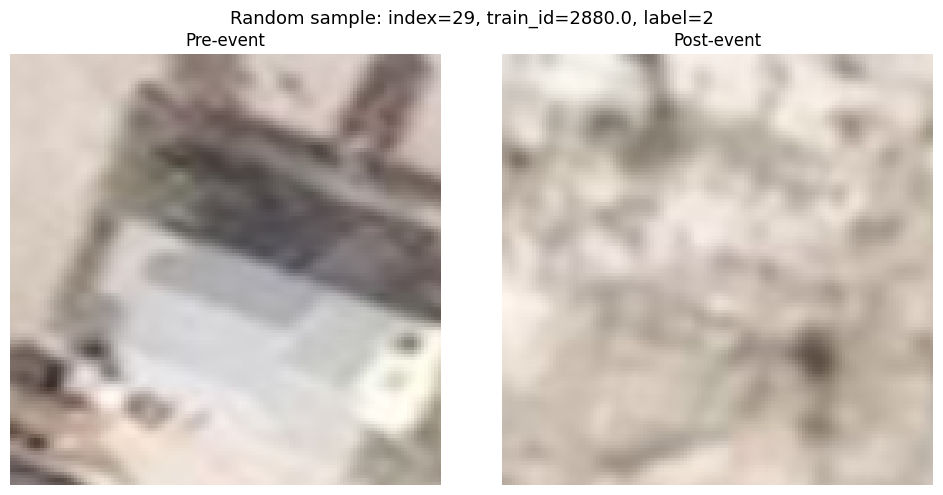

```python
# Quick visual check: randomly inspect one processed sample
sample_idx = np.random.randint(len(y))

fig, axes = plt.subplots(1, 2, figsize=(10, 5))
axes[0].imshow(pre_chips[sample_idx])
axes[0].set_title("Pre-event")
axes[0].axis("off")

axes[1].imshow(post_chips[sample_idx])
axes[1].set_title("Post-event")
axes[1].axis("off")

label_value = y[sample_idx]
train_id_value = metadata_df.iloc[sample_idx]["train_id"]
fig.suptitle(f"Random sample: index={sample_idx}, train_id={train_id_value}, label={label_value}", fontsize=13)
plt.tight_layout()
plt.show()
```

#### 0.4 Train / Validation / Test Split

```python
from sklearn.model_selection import train_test_split

# First split: 70% train, 30% temporary holdout for validation + test
all_indices = np.arange(len(y))

train_idx, temp_idx = train_test_split(
    all_indices,
    test_size=0.30,
    stratify=y,
    random_state=42,
)

# Second split: split the 30% holdout evenly into 15% validation and 15% test
val_idx, test_idx = train_test_split(
    temp_idx,
    test_size=0.50,
    stratify=y[temp_idx],
    random_state=42,
)

# Split metadata so each processed chip can still be traced back to its building footprint
meta_train = metadata_df.iloc[train_idx].reset_index(drop=True)
meta_val = metadata_df.iloc[val_idx].reset_index(drop=True)
meta_test = metadata_df.iloc[test_idx].reset_index(drop=True)

# Split the aligned pre/post chips and labels with the same indices
pre_train, pre_val, pre_test = pre_chips[train_idx], pre_chips[val_idx], pre_chips[test_idx]
post_train, post_val, post_test = post_chips[train_idx], post_chips[val_idx], post_chips[test_idx]
y_train, y_val, y_test = y[train_idx], y[val_idx], y[test_idx]

# Store each split in a dictionary to keep later training cells clean
train_data = {
    "metadata": meta_train,
    "pre": pre_train,
    "post": post_train,
    "y": y_train,
}

val_data = {
    "metadata": meta_val,
    "pre": pre_val,
    "post": post_val,
    "y": y_val,
}

test_data = {
    "metadata": meta_test,
    "pre": pre_test,
    "post": post_test,
    "y": y_test,
}

def print_split_summary(name, labels):
    counts = pd.Series(labels).value_counts().sort_index()
    print(f"{name} set size: {len(labels)}")
    for label_value, count in counts.items():
        print(f"  label {label_value}: {count}")


print_split_summary("Train", y_train)
print()
print_split_summary("Validation", y_val)
print()
print_split_summary("Test", y_test)
```

```
Train set size: 319
  label 0: 98
  label 1: 141
  label 2: 80

Validation set size: 69
  label 0: 21
  label 1: 30
  label 2: 18

Test set size: 69
  label 0: 21
  label 1: 31
  label 2: 17
```

### 1. Model 1: simple CNN, by labeled data

```python
import tensorflow as tf
from tensorflow.keras import Sequential
from tensorflow.keras.layers import Conv2D, MaxPooling2D, Flatten, Dense
from tensorflow.keras.utils import plot_model
from IPython.display import Image, display

# Use post-event chips for the first CNN baseline
X_train_cnn = post_train.astype("float32") / 255.0
X_val_cnn = post_val.astype("float32") / 255.0
X_test_cnn = post_test.astype("float32") / 255.0

# Keep labels as integer class ids: 0, 1, 2
y_train_cnn = y_train
y_val_cnn = y_val
y_test_cnn = y_test

# Simple 3-layer CNN for 3-class building damage classification
model_1 = Sequential([
    Conv2D(32, (3, 3), activation="relu", input_shape=(128, 128, 3)),
    MaxPooling2D((2, 2)),
    Conv2D(64, (3, 3), activation="relu"),
    MaxPooling2D((2, 2)),
    Conv2D(128, (3, 3), activation="relu"),
    MaxPooling2D((2, 2)),
    Flatten(),
    Dense(128, activation="relu"),
    Dense(3, activation="softmax")
], name="simple_cnn_3class")

# Keep the optimizer at its default Keras settings
model_1.compile(
    optimizer="adam",
    loss="sparse_categorical_crossentropy",
    metrics=["accuracy"]
)

model_1.summary()
```

```
Model: "simple_cnn_3class"
```

```
┏━━━━━━━━━━━━━━━━━━━━━━━━━━━━━━━━━┳━━━━━━━━━━━━━━━━━━━━━━━━┳━━━━━━━━━━━━━━━┓
┃ Layer (type)                    ┃ Output Shape           ┃       Param # ┃
┡━━━━━━━━━━━━━━━━━━━━━━━━━━━━━━━━━╇━━━━━━━━━━━━━━━━━━━━━━━━╇━━━━━━━━━━━━━━━┩
│ conv2d_3 (Conv2D)               │ (None, 126, 126, 32)   │           896 │
├─────────────────────────────────┼────────────────────────┼───────────────┤
│ max_pooling2d_3 (MaxPooling2D)  │ (None, 63, 63, 32)     │             0 │
├─────────────────────────────────┼────────────────────────┼───────────────┤
│ conv2d_4 (Conv2D)               │ (None, 61, 61, 64)     │        18,496 │
├─────────────────────────────────┼────────────────────────┼───────────────┤
│ max_pooling2d_4 (MaxPooling2D)  │ (None, 30, 30, 64)     │             0 │
├─────────────────────────────────┼────────────────────────┼───────────────┤
│ conv2d_5 (Conv2D)               │ (None, 28, 28, 128)    │        73,856 │
├─────────────────────────────────┼────────────────────────┼───────────────┤
│ max_pooling2d_5 (MaxPooling2D)  │ (None, 14, 14, 128)    │             0 │
├─────────────────────────────────┼────────────────────────┼───────────────┤
│ flatten_1 (Flatten)             │ (None, 25088)          │             0 │
├─────────────────────────────────┼────────────────────────┼───────────────┤
│ dense_2 (Dense)                 │ (None, 128)            │     3,211,392 │
├─────────────────────────────────┼────────────────────────┼───────────────┤
│ dense_3 (Dense)                 │ (None, 3)              │           387 │
└─────────────────────────────────┴────────────────────────┴───────────────┘
```

```
 Total params: 3,305,027 (12.61 MB)
```

```
 Trainable params: 3,305,027 (12.61 MB)
```

```
 Non-trainable params: 0 (0.00 B)
```

```python
from tensorflow.keras.callbacks import ModelCheckpoint

# Save the best model on validation loss during training
checkpoint_model_1 = ModelCheckpoint(
    filepath="best_model_1_simple_cnn.keras",
    monitor="val_loss",
    save_best_only=True,
    mode="min",
    verbose=1,
)

print("Training Model 1: simple 3-layer CNN...")
history_model_1 = model_1.fit(
    X_train_cnn,
    y_train_cnn,
    epochs=100,
    validation_data=(X_val_cnn, y_val_cnn),
    callbacks=[checkpoint_model_1],
    verbose=1,
)

# Reload the best checkpoint before final evaluation on the held-out test set
best_model_1 = tf.keras.models.load_model("best_model_1_simple_cnn.keras")
test_loss_model_1, test_acc_model_1 = best_model_1.evaluate(X_test_cnn, y_test_cnn, verbose=0)

print(f"\nModel 1 test loss: {test_loss_model_1:.4f}")
print(f"Model 1 test accuracy: {test_acc_model_1:.4f}")
```

```
Training Model 1: simple 3-layer CNN...
10/10 ━━━━━━━━━━━━━━━━━━━━ 0s 203ms/step - accuracy: 0.3707 - loss: 1.2618
Epoch 1: val_loss improved from None to 1.07312, saving model to best_model_1_simple_cnn.keras

Epoch 1: finished saving model to best_model_1_simple_cnn.keras
10/10 ━━━━━━━━━━━━━━━━━━━━ 7s 379ms/step - accuracy: 0.4138 - loss: 1.1800 - val_accuracy: 0.4348 - val_loss: 1.0731
10/10 ━━━━━━━━━━━━━━━━━━━━ 0s 6ms/step - accuracy: 0.4513 - loss: 1.0663
Epoch 2: val_loss improved from 1.07312 to 1.06106, saving model to best_model_1_simple_cnn.keras

Epoch 2: finished saving model to best_model_1_simple_cnn.keras
10/10 ━━━━━━━━━━━━━━━━━━━━ 0s 35ms/step - accuracy: 0.4420 - loss: 1.0655 - val_accuracy: 0.4348 - val_loss: 1.0611
10/10 ━━━━━━━━━━━━━━━━━━━━ 0s 6ms/step - accuracy: 0.4369 - loss: 1.0403
Epoch 3: val_loss improved from 1.06106 to 1.00979, saving model to best_model_1_simple_cnn.keras

Epoch 3: finished saving model to best_model_1_simple_cnn.keras
10/10 ━━━━━━━━━━━━━━━━━━━━ 0s 33ms/step - accuracy: 0.4420 - loss: 1.0205 - val_accuracy: 0.4348 - val_loss: 1.0098
10/10 ━━━━━━━━━━━━━━━━━━━━ 0s 6ms/step - accuracy: 0.4708 - loss: 0.9643
Epoch 4: val_loss did not improve from 1.00979
10/10 ━━━━━━━━━━━━━━━━━━━━ 0s 16ms/step - accuracy: 0.5047 - loss: 0.9409 - val_accuracy: 0.5507 - val_loss: 1.0187
10/10 ━━━━━━━━━━━━━━━━━━━━ 0s 6ms/step - accuracy: 0.5224 - loss: 0.9312
Epoch 5: val_loss improved from 1.00979 to 1.00485, saving model to best_model_1_simple_cnn.keras

Epoch 5: finished saving model to best_model_1_simple_cnn.keras
10/10 ━━━━━━━━━━━━━━━━━━━━ 0s 34ms/step - accuracy: 0.5235 - loss: 0.9261 - val_accuracy: 0.4928 - val_loss: 1.0048
10/10 ━━━━━━━━━━━━━━━━━━━━ 0s 6ms/step - accuracy: 0.5675 - loss: 0.8649
Epoch 6: val_loss improved from 1.00485 to 0.97046, saving model to best_model_1_simple_cnn.keras

Epoch 6: finished saving model to best_model_1_simple_cnn.keras
10/10 ━━━━━━━━━━━━━━━━━━━━ 0s 34ms/step - accuracy: 0.5705 - loss: 0.8602 - val_accuracy: 0.4493 - val_loss: 0.9705
10/10 ━━━━━━━━━━━━━━━━━━━━ 0s 6ms/step - accuracy: 0.5623 - loss: 0.8514
Epoch 7: val_loss improved from 0.97046 to 0.95227, saving model to best_model_1_simple_cnn.keras

Epoch 7: finished saving model to best_model_1_simple_cnn.keras
10/10 ━━━━━━━━━━━━━━━━━━━━ 0s 35ms/step - accuracy: 0.5705 - loss: 0.8673 - val_accuracy: 0.4348 - val_loss: 0.9523
10/10 ━━━━━━━━━━━━━━━━━━━━ 0s 6ms/step - accuracy: 0.5746 - loss: 0.8356
Epoch 8: val_loss improved from 0.95227 to 0.92413, saving model to best_model_1_simple_cnn.keras

Epoch 8: finished saving model to best_model_1_simple_cnn.keras
10/10 ━━━━━━━━━━━━━━━━━━━━ 0s 33ms/step - accuracy: 0.6082 - loss: 0.7857 - val_accuracy: 0.5217 - val_loss: 0.9241
10/10 ━━━━━━━━━━━━━━━━━━━━ 0s 6ms/step - accuracy: 0.6527 - loss: 0.7844
```

[output cut: 263 more lines]

```
10/10 ━━━━━━━━━━━━━━━━━━━━ 0s 6ms/step - accuracy: 1.0000 - loss: 7.0599e-05
Epoch 97: val_loss did not improve from 0.92413
10/10 ━━━━━━━━━━━━━━━━━━━━ 0s 16ms/step - accuracy: 1.0000 - loss: 7.7080e-05 - val_accuracy: 0.5362 - val_loss: 4.2919
10/10 ━━━━━━━━━━━━━━━━━━━━ 0s 6ms/step - accuracy: 1.0000 - loss: 7.9087e-05
Epoch 98: val_loss did not improve from 0.92413
10/10 ━━━━━━━━━━━━━━━━━━━━ 0s 15ms/step - accuracy: 1.0000 - loss: 7.5817e-05 - val_accuracy: 0.5362 - val_loss: 4.2988
10/10 ━━━━━━━━━━━━━━━━━━━━ 0s 6ms/step - accuracy: 1.0000 - loss: 7.7430e-05
Epoch 99: val_loss did not improve from 0.92413
10/10 ━━━━━━━━━━━━━━━━━━━━ 0s 16ms/step - accuracy: 1.0000 - loss: 7.4931e-05 - val_accuracy: 0.5362 - val_loss: 4.3017
10/10 ━━━━━━━━━━━━━━━━━━━━ 0s 6ms/step - accuracy: 1.0000 - loss: 7.0100e-05
Epoch 100: val_loss did not improve from 0.92413
10/10 ━━━━━━━━━━━━━━━━━━━━ 0s 15ms/step - accuracy: 1.0000 - loss: 7.3148e-05 - val_accuracy: 0.5217 - val_loss: 4.3094

Model 1 test loss: 1.0397
Model 1 test accuracy: 0.4348
```

### 2. Model 2: xBD Baseline Model

#### 2.1 Original Arcitecture: baseline model

```
Input shape:  (None, 128, 128, 3)
Output shape: (None, 4)

Main branch outputs:
- Shallow CNN branch  (flatten_1): (None, 16384)
- ResNet50 branch     (flatten_2): (None, 32768)
- Concatenated vector            : (None, 49152)

Compact architecture view (ResNet50 kept as one block):
```

```
Model: "xbd_baseline_classifier_viz"
```

```
┏━━━━━━━━━━━━━━━━━━━━━━━━━━━━━━━━━━━┳━━━━━━━━━━━━━━━━━━━━━━━━━━━━━━┳━━━━━━━━━━━━━━━━━━━┳━━━━━━━━━━━━━━━━━━━━━━━━━━━
┃ Layer (type)                      ┃ Output Shape                 ┃           Param # ┃ Connected to
┡━━━━━━━━━━━━━━━━━━━━━━━━━━━━━━━━━━━╇━━━━━━━━━━━━━━━━━━━━━━━━━━━━━━╇━━━━━━━━━━━━━━━━━━━╇━━━━━━━━━━━━━━━━━━━━━━━━━━━
│ input_1 (InputLayer)              │ (None, 128, 128, 3)          │                 0 │ -
├───────────────────────────────────┼──────────────────────────────┼───────────────────┼───────────────────────────
│ conv2d_1 (Conv2D)                 │ (None, 128, 128, 32)         │             2,432 │ input_1[0][0]
├───────────────────────────────────┼──────────────────────────────┼───────────────────┼───────────────────────────
│ max_pooling2d_2 (MaxPooling2D)    │ (None, 64, 64, 32)           │                 0 │ conv2d_1[0][0]
├───────────────────────────────────┼──────────────────────────────┼───────────────────┼───────────────────────────
│ conv2d_2 (Conv2D)                 │ (None, 64, 64, 64)           │            18,496 │ max_pooling2d_2[0][0]
├───────────────────────────────────┼──────────────────────────────┼───────────────────┼───────────────────────────
│ max_pooling2d_3 (MaxPooling2D)    │ (None, 32, 32, 64)           │                 0 │ conv2d_2[0][0]
├───────────────────────────────────┼──────────────────────────────┼───────────────────┼───────────────────────────
│ conv2d_3 (Conv2D)                 │ (None, 32, 32, 64)           │            36,928 │ max_pooling2d_3[0][0]
├───────────────────────────────────┼──────────────────────────────┼───────────────────┼───────────────────────────
│ max_pooling2d_4 (MaxPooling2D)    │ (None, 16, 16, 64)           │                 0 │ conv2d_3[0][0]
├───────────────────────────────────┼──────────────────────────────┼───────────────────┼───────────────────────────
│ resnet50 (Functional)             │ (None, 4, 4, 2048)           │        23,587,712 │ input_1[0][0]
├───────────────────────────────────┼──────────────────────────────┼───────────────────┼───────────────────────────
│ flatten_1 (Flatten)               │ (None, 16384)                │                 0 │ max_pooling2d_4[0][0]
├───────────────────────────────────┼──────────────────────────────┼───────────────────┼───────────────────────────
│ flatten_2 (Flatten)               │ (None, 32768)                │                 0 │ resnet50[0][0]
├───────────────────────────────────┼──────────────────────────────┼───────────────────┼───────────────────────────
│ concatenate_1 (Concatenate)       │ (None, 49152)                │                 0 │ flatten_1[0][0],
│                                   │                              │                   │ flatten_2[0][0]
├───────────────────────────────────┼──────────────────────────────┼───────────────────┼───────────────────────────
│ dense_1 (Dense)                   │ (None, 2024)                 │        99,485,672 │ concatenate_1[0][0]
├───────────────────────────────────┼──────────────────────────────┼───────────────────┼───────────────────────────
│ dense_2 (Dense)                   │ (None, 524)                  │         1,061,100 │ dense_1[0][0]
├───────────────────────────────────┼──────────────────────────────┼───────────────────┼───────────────────────────
│ dense_3 (Dense)                   │ (None, 124)                  │            65,100 │ dense_2[0][0]
├───────────────────────────────────┼──────────────────────────────┼───────────────────┼───────────────────────────
│ dense_4 (Dense)                   │ (None, 4)                    │               500 │ dense_3[0][0]
└───────────────────────────────────┴──────────────────────────────┴───────────────────┴───────────────────────────
```

```
 Total params: 124,257,940 (474.01 MB)
```

```
 Trainable params: 124,204,820 (473.80 MB)
```

```
 Non-trainable params: 53,120 (207.50 KB)
```

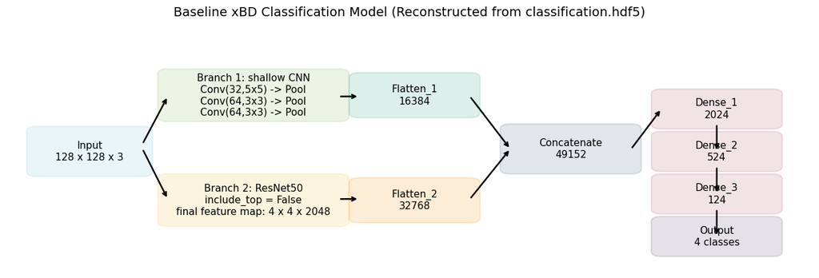

```python
import matplotlib.pyplot as plt
from matplotlib.patches import FancyBboxPatch
import tensorflow as tf
from tensorflow.keras import layers, Model

INPUT_SHAPE = (128, 128, 3)
WEIGHTS_PATH = "/content/drive/MyDrive/data/classification.hdf5"


def build_baseline_model_for_loading(input_shape=INPUT_SHAPE):
    """Rebuild the original xBD baseline in a form that matches the saved weights."""
    inputs = tf.keras.Input(shape=input_shape, name="input_1")

    # Branch 1: shallow CNN for local texture and roof-level details
    branch_1 = layers.Conv2D(32, (5, 5), activation="relu", padding="same", name="conv2d_1")(inputs)
    branch_1 = layers.MaxPooling2D((2, 2), name="max_pooling2d_2")(branch_1)
    branch_1 = layers.Conv2D(64, (3, 3), activation="relu", padding="same", name="conv2d_2")(branch_1)
    branch_1 = layers.MaxPooling2D((2, 2), name="max_pooling2d_3")(branch_1)
    branch_1 = layers.Conv2D(64, (3, 3), activation="relu", padding="same", name="conv2d_3")(branch_1)
    branch_1 = layers.MaxPooling2D((2, 2), name="max_pooling2d_4")(branch_1)
    branch_1 = layers.Flatten(name="flatten_1")(branch_1)

    # Branch 2: ResNet50 backbone for higher-level semantic/context features
    resnet_backbone = tf.keras.applications.ResNet50(
        include_top=False,
        weights=None,
        input_tensor=inputs,
    )
    branch_2 = layers.Flatten(name="flatten_2")(resnet_backbone.output)

    merged = layers.Concatenate(name="concatenate_1")([branch_1, branch_2])
    x = layers.Dense(2024, activation="relu", name="dense_1")(merged)
    x = layers.Dense(524, activation="relu", name="dense_2")(x)
    x = layers.Dense(124, activation="relu", name="dense_3")(x)
    outputs = layers.Dense(4, activation="softmax", name="dense_4")(x)

    return Model(inputs=inputs, outputs=outputs, name="xbd_baseline_classifier")


def build_baseline_model_viz(input_shape=INPUT_SHAPE):
    """Compact visualization model: keep ResNet50 as one block in the graph/summary."""
    inputs = tf.keras.Input(shape=input_shape, name="input_1")

    branch_1 = layers.Conv2D(32, (5, 5), activation="relu", padding="same", name="conv2d_1")(inputs)
    branch_1 = layers.MaxPooling2D((2, 2), name="max_pooling2d_2")(branch_1)
    branch_1 = layers.Conv2D(64, (3, 3), activation="relu", padding="same", name="conv2d_2")(branch_1)
    branch_1 = layers.MaxPooling2D((2, 2), name="max_pooling2d_3")(branch_1)
    branch_1 = layers.Conv2D(64, (3, 3), activation="relu", padding="same", name="conv2d_3")(branch_1)
    branch_1 = layers.MaxPooling2D((2, 2), name="max_pooling2d_4")(branch_1)
    branch_1 = layers.Flatten(name="flatten_1")(branch_1)

    resnet_backbone = tf.keras.applications.ResNet50(
        include_top=False,
        weights=None,
        input_shape=input_shape,
    )
    branch_2 = layers.Flatten(name="flatten_2")(resnet_backbone(inputs))

    merged = layers.Concatenate(name="concatenate_1")([branch_1, branch_2])
    x = layers.Dense(2024, activation="relu", name="dense_1")(merged)
    x = layers.Dense(524, activation="relu", name="dense_2")(x)
    x = layers.Dense(124, activation="relu", name="dense_3")(x)
    outputs = layers.Dense(4, activation="softmax", name="dense_4")(x)

    return Model(inputs=inputs, outputs=outputs, name="xbd_baseline_classifier_viz")


def draw_baseline_schematic():
    """Draw a compact hand-crafted schematic of the reconstructed baseline model."""
    fig, ax = plt.subplots(figsize=(16, 5))
    ax.set_xlim(0, 16)
    ax.set_ylim(0, 10)
    ax.axis("off")

    def box(x, y, w, h, text, color):
        patch = FancyBboxPatch(
            (x, y), w, h,
            boxstyle="round,pad=0.2",
            linewidth=1.5,
            edgecolor=color,
            facecolor=color,
            alpha=0.18,
        )
        ax.add_patch(patch)
        ax.text(x + w / 2, y + h / 2, text, ha="center", va="center", fontsize=11)

    box(0.6, 4.0, 2.1, 1.6, "Input\n128 x 128 x 3", "#8ecae6")

    box(3.2, 6.2, 3.4, 1.7, "Branch 1: shallow CNN\nConv(32,5x5) -> Pool\nConv(64,3x3) -> Pool\nConv(64,3x3) -> Pool", "#90be6d")
    box(3.2, 2.0, 3.4, 1.7, "Branch 2: ResNet50\ninclude_top = False\nfinal feature map: 4 x 4 x 2048", "#f9c74f")

    box(7.0, 6.35, 2.2, 1.4, "Flatten_1\n16384", "#43aa8b")
    box(7.0, 2.15, 2.2, 1.4, "Flatten_2\n32768", "#f8961e")
    box(10.0, 4.1, 2.4, 1.6, "Concatenate\n49152", "#577590")
    box(13.0, 5.9, 2.2, 1.2, "Dense_1\n2024", "#b56576")
    box(13.0, 4.2, 2.2, 1.2, "Dense_2\n524", "#b56576")
    box(13.0, 2.5, 2.2, 1.2, "Dense_3\n124", "#b56576")
    box(13.0, 0.8, 2.2, 1.2, "Output\n4 classes", "#6d597a")

    ax.annotate("", xy=(3.2, 7.0), xytext=(2.7, 5.1), arrowprops=dict(arrowstyle="->", lw=1.8))
    ax.annotate("", xy=(3.2, 2.9), xytext=(2.7, 4.9), arrowprops=dict(arrowstyle="->", lw=1.8))
    ax.annotate("", xy=(7.0, 7.0), xytext=(6.6, 7.0), arrowprops=dict(arrowstyle="->", lw=1.8))
    ax.annotate("", xy=(7.0, 2.9), xytext=(6.6, 2.9), arrowprops=dict(arrowstyle="->", lw=1.8))
    ax.annotate("", xy=(10.0, 4.9), xytext=(9.2, 7.0), arrowprops=dict(arrowstyle="->", lw=1.8))
    ax.annotate("", xy=(10.0, 4.9), xytext=(9.2, 2.9), arrowprops=dict(arrowstyle="->", lw=1.8))
    ax.annotate("", xy=(13.0, 6.5), xytext=(12.4, 4.9), arrowprops=dict(arrowstyle="->", lw=1.8))
    ax.annotate("", xy=(14.1, 4.8), xytext=(14.1, 5.9), arrowprops=dict(arrowstyle="->", lw=1.8))
    ax.annotate("", xy=(14.1, 3.1), xytext=(14.1, 4.2), arrowprops=dict(arrowstyle="->", lw=1.8))
    ax.annotate("", xy=(14.1, 1.4), xytext=(14.1, 2.5), arrowprops=dict(arrowstyle="->", lw=1.8))

    ax.set_title("Baseline xBD Classification Model (Reconstructed from classification.hdf5)", fontsize=14)
    plt.show()


baseline = build_baseline_model_for_loading()
baseline_viz = build_baseline_model_viz()
baseline.load_weights(WEIGHTS_PATH, by_name=True)

print(f"Input shape:  {baseline.input_shape}")
print(f"Output shape: {baseline.output_shape}")
print("\nMain branch outputs:")
print("- Shallow CNN branch  (flatten_1):", baseline.get_layer("flatten_1").output.shape)
print("- ResNet50 branch     (flatten_2):", baseline.get_layer("flatten_2").output.shape)
print("- Concatenated vector            :", baseline.get_layer("concatenate_1").output.shape)

print("\nCompact architecture view (ResNet50 kept as one block):")
baseline_viz.summary(line_length=120, expand_nested=False)

draw_baseline_schematic()
```

#### 2.2 Predict by xBD baseline model (without fine-tuning)

```python
from sklearn.metrics import accuracy_score

# The original xBD baseline expects post-disaster RGB chips as input
X_test_baseline = post_test.astype("float32") / 255.0

# Run direct inference without any fine-tuning
baseline_probs = baseline.predict(X_test_baseline, verbose=0)
baseline_pred_4class = np.argmax(baseline_probs, axis=1)

# Map the original 4 xBD classes into the 3-class local label scheme
# xBD: 0=no-damage, 1=minor, 2=major, 3=destroyed
# Local: 0 -> 0, (1 or 2) -> 1, 3 -> 2
xbd_to_local_map = np.array([0, 1, 1, 2])
baseline_pred_3class = xbd_to_local_map[baseline_pred_4class]

# Accuracy is computed only after remapping into the local 3-class label space
baseline_test_accuracy = accuracy_score(y_test, baseline_pred_3class)

# Print all original xBD classes, including classes with zero predictions
pred4_counts = pd.Series(baseline_pred_4class).value_counts().reindex([0, 1, 2, 3], fill_value=0)
print("xBD original 4-class prediction counts on the local test set:")
for class_id, count in pred4_counts.items():
    print(f"  xBD class {class_id}: {count}")

# Print all remapped local classes, including classes with zero predictions
pred3_counts = pd.Series(baseline_pred_3class).value_counts().reindex([0, 1, 2], fill_value=0)
print("\nRemapped 3-class prediction counts:")
for class_id, count in pred3_counts.items():
    print(f"  local class {class_id}: {count}")

print(f"\nModel 2 test accuracy (computed after 4-class -> 3-class remapping): {baseline_test_accuracy:.4f}")
```

```
xBD original 4-class prediction counts on the local test set:
  xBD class 0: 62
  xBD class 1: 0
  xBD class 2: 7
  xBD class 3: 0

Remapped 3-class prediction counts:
  local class 0: 62
  local class 1: 7
  local class 2: 0

Model 2 test accuracy (computed after 4-class -> 3-class remapping): 0.2754
```

### 3. Fine-tuning

#### 3.1 Model 3: Fine-tuning model, with only post-iamge

For this first fine-tuning experiment, we use the xBD baseline as a pretrained starting point and load the saved weights from `classification.hdf5`. We keep the ResNet50 backbone frozen so that its pretrained high-level feature extractor remains fixed. The trainable part includes the shallow CNN branch (`conv2d_1`-`conv2d_3`), the original classification head (`dense_1`-`dense_3`), and a new 3-class output layer that replaces the original 4-class output. In other words, this strategy performs post-event, transfer-learning-based fine-tuning by adapting only the lighter task-specific layers to the local label scheme while preserving the heavier pretrained backbone.

```python
from tensorflow.keras import Model
from tensorflow.keras.layers import Dense
from tensorflow.keras.utils import plot_model
from IPython.display import Image, display

# Use only post-event chips for this first fine-tuning experiment
X_train_ft = post_train.astype("float32") / 255.0
X_val_ft = post_val.astype("float32") / 255.0
X_test_ft = post_test.astype("float32") / 255.0

y_train_ft = y_train
y_val_ft = y_val
y_test_ft = y_test

# Rebuild the original xBD baseline and load its pretrained weights
ft_base = build_baseline_model_for_loading()
ft_base.load_weights(WEIGHTS_PATH, by_name=True)

# Freeze the ResNet50 backbone, but keep the shallow CNN branch trainable
custom_branch_layers = {
    "input_1",
    "conv2d_1",
    "max_pooling2d_2",
    "conv2d_2",
    "max_pooling2d_3",
    "conv2d_3",
    "max_pooling2d_4",
    "flatten_1",
    "flatten_2",
    "concatenate_1",
    "dense_1",
    "dense_2",
    "dense_3",
    "dense_4",
}

for layer in ft_base.layers:
    if layer.name not in custom_branch_layers:
        layer.trainable = False

# Keep the small CNN branch trainable
for layer_name in ["conv2d_1", "conv2d_2", "conv2d_3"]:
    ft_base.get_layer(layer_name).trainable = True

# Keep the classification head trainable
for layer_name in ["dense_1", "dense_2", "dense_3"]:
    ft_base.get_layer(layer_name).trainable = True

# Replace the original 4-class output layer with a new 3-class output layer
ft_features = ft_base.get_layer("dense_3").output
ft_outputs = Dense(3, activation="softmax", name="ft_predictions")(ft_features)
model_3 = Model(inputs=ft_base.input, outputs=ft_outputs, name="xbd_post_only_finetune_3class")

model_3.compile(
    optimizer=tf.keras.optimizers.Adam(learning_rate=1e-4),
    loss="sparse_categorical_crossentropy",
    metrics=["accuracy"],
)

# Build a compact visualization model so ResNet50 stays as one block in the summary/diagram
ft_viz_base = build_baseline_model_viz()

for layer in ft_viz_base.layers:
    if layer.name not in custom_branch_layers:
        layer.trainable = False

for layer_name in ["conv2d_1", "conv2d_2", "conv2d_3", "dense_1", "dense_2", "dense_3"]:
    ft_viz_base.get_layer(layer_name).trainable = True

ft_viz_features = ft_viz_base.get_layer("dense_3").output
ft_viz_outputs = Dense(3, activation="softmax", name="ft_predictions")(ft_viz_features)
model_3_viz = Model(inputs=ft_viz_base.input, outputs=ft_viz_outputs, name="xbd_post_only_finetune_3class_viz")

print("Trainable layers in Model 3:")
for layer in model_3.layers:
    if layer.trainable:
        print(" -", layer.name)

print("\nCompact architecture view (ResNet50 kept as one block):")
model_3_viz.summary(line_length=120, expand_nested=False)
```

```
Trainable layers in Model 3:
 - input_1
 - conv2d_1
 - max_pooling2d_2
 - conv2d_2
 - max_pooling2d_3
 - conv2d_3
 - max_pooling2d_4
 - flatten_1
 - flatten_2
 - concatenate_1
 - dense_1
 - dense_2
 - dense_3
 - ft_predictions

Compact architecture view (ResNet50 kept as one block):
```

```
Model: "xbd_post_only_finetune_3class_viz"
```

```
┏━━━━━━━━━━━━━━━━━━━━━━━━━━━━━━━━━━━┳━━━━━━━━━━━━━━━━━━━━━━━━━━━━━━┳━━━━━━━━━━━━━━━━━━━┳━━━━━━━━━━━━━━━━━━━━━━━━━━━
┃ Layer (type)                      ┃ Output Shape                 ┃           Param # ┃ Connected to
┡━━━━━━━━━━━━━━━━━━━━━━━━━━━━━━━━━━━╇━━━━━━━━━━━━━━━━━━━━━━━━━━━━━━╇━━━━━━━━━━━━━━━━━━━╇━━━━━━━━━━━━━━━━━━━━━━━━━━━
│ input_1 (InputLayer)              │ (None, 128, 128, 3)          │                 0 │ -
├───────────────────────────────────┼──────────────────────────────┼───────────────────┼───────────────────────────
│ conv2d_1 (Conv2D)                 │ (None, 128, 128, 32)         │             2,432 │ input_1[0][0]
├───────────────────────────────────┼──────────────────────────────┼───────────────────┼───────────────────────────
│ max_pooling2d_2 (MaxPooling2D)    │ (None, 64, 64, 32)           │                 0 │ conv2d_1[0][0]
├───────────────────────────────────┼──────────────────────────────┼───────────────────┼───────────────────────────
│ conv2d_2 (Conv2D)                 │ (None, 64, 64, 64)           │            18,496 │ max_pooling2d_2[0][0]
├───────────────────────────────────┼──────────────────────────────┼───────────────────┼───────────────────────────
│ max_pooling2d_3 (MaxPooling2D)    │ (None, 32, 32, 64)           │                 0 │ conv2d_2[0][0]
├───────────────────────────────────┼──────────────────────────────┼───────────────────┼───────────────────────────
│ conv2d_3 (Conv2D)                 │ (None, 32, 32, 64)           │            36,928 │ max_pooling2d_3[0][0]
├───────────────────────────────────┼──────────────────────────────┼───────────────────┼───────────────────────────
│ max_pooling2d_4 (MaxPooling2D)    │ (None, 16, 16, 64)           │                 0 │ conv2d_3[0][0]
├───────────────────────────────────┼──────────────────────────────┼───────────────────┼───────────────────────────
│ resnet50 (Functional)             │ (None, 4, 4, 2048)           │        23,587,712 │ input_1[0][0]
├───────────────────────────────────┼──────────────────────────────┼───────────────────┼───────────────────────────
│ flatten_1 (Flatten)               │ (None, 16384)                │                 0 │ max_pooling2d_4[0][0]
├───────────────────────────────────┼──────────────────────────────┼───────────────────┼───────────────────────────
│ flatten_2 (Flatten)               │ (None, 32768)                │                 0 │ resnet50[0][0]
├───────────────────────────────────┼──────────────────────────────┼───────────────────┼───────────────────────────
│ concatenate_1 (Concatenate)       │ (None, 49152)                │                 0 │ flatten_1[0][0],
│                                   │                              │                   │ flatten_2[0][0]
├───────────────────────────────────┼──────────────────────────────┼───────────────────┼───────────────────────────
│ dense_1 (Dense)                   │ (None, 2024)                 │        99,485,672 │ concatenate_1[0][0]
├───────────────────────────────────┼──────────────────────────────┼───────────────────┼───────────────────────────
│ dense_2 (Dense)                   │ (None, 524)                  │         1,061,100 │ dense_1[0][0]
├───────────────────────────────────┼──────────────────────────────┼───────────────────┼───────────────────────────
│ dense_3 (Dense)                   │ (None, 124)                  │            65,100 │ dense_2[0][0]
├───────────────────────────────────┼──────────────────────────────┼───────────────────┼───────────────────────────
│ ft_predictions (Dense)            │ (None, 3)                    │               375 │ dense_3[0][0]
└───────────────────────────────────┴──────────────────────────────┴───────────────────┴───────────────────────────
```

```
 Total params: 124,257,815 (474.01 MB)
```

```
 Trainable params: 100,670,103 (384.03 MB)
```

```
 Non-trainable params: 23,587,712 (89.98 MB)
```

```python
from tensorflow.keras.callbacks import ModelCheckpoint

# Save the best fine-tuned model according to validation loss
checkpoint_model_3 = ModelCheckpoint(
    filepath="best_model_3_post_only_finetune.keras",
    monitor="val_loss",
    save_best_only=True,
    mode="min",
    verbose=1,
)

print("Training Model 3: post-only 3-class fine-tuning...")
history_model_3 = model_3.fit(
    X_train_ft,
    y_train_ft,
    epochs=100,
    validation_data=(X_val_ft, y_val_ft),
    callbacks=[checkpoint_model_3],
    verbose=1,
)

# Load the best checkpoint before evaluating on the held-out test set
best_model_3 = tf.keras.models.load_model("best_model_3_post_only_finetune.keras")
test_loss_model_3, test_acc_model_3 = best_model_3.evaluate(X_test_ft, y_test_ft, verbose=0)

print(f"\nModel 3 test loss: {test_loss_model_3:.4f}")
print(f"Model 3 test accuracy: {test_acc_model_3:.4f}")
```

```
Training Model 3: post-only 3-class fine-tuning...
10/10 ━━━━━━━━━━━━━━━━━━━━ 0s 2s/step - accuracy: 0.3314 - loss: 47.8005
Epoch 1: val_loss improved from None to 15.98168, saving model to best_model_3_post_only_finetune.keras

Epoch 1: finished saving model to best_model_3_post_only_finetune.keras
10/10 ━━━━━━━━━━━━━━━━━━━━ 45s 3s/step - accuracy: 0.3072 - loss: 39.4424 - val_accuracy: 0.3043 - val_loss: 15.9817
 8/10 ━━━━━━━━━━━━━━━━━━━━ 0s 17ms/step - accuracy: 0.3327 - loss: 12.7130
Epoch 2: val_loss improved from 15.98168 to 3.36694, saving model to best_model_3_post_only_finetune.keras

Epoch 2: finished saving model to best_model_3_post_only_finetune.keras
10/10 ━━━━━━━━━━━━━━━━━━━━ 9s 966ms/step - accuracy: 0.3417 - loss: 7.5174 - val_accuracy: 0.4058 - val_loss: 3.3669
 8/10 ━━━━━━━━━━━━━━━━━━━━ 0s 17ms/step - accuracy: 0.4785 - loss: 3.8314
Epoch 3: val_loss improved from 3.36694 to 3.10516, saving model to best_model_3_post_only_finetune.keras

Epoch 3: finished saving model to best_model_3_post_only_finetune.keras
10/10 ━━━━━━━━━━━━━━━━━━━━ 6s 607ms/step - accuracy: 0.4389 - loss: 4.0504 - val_accuracy: 0.4058 - val_loss: 3.1052
 7/10 ━━━━━━━━━━━━━━━━━━━━ 0s 17ms/step - accuracy: 0.3723 - loss: 3.0215
Epoch 4: val_loss improved from 3.10516 to 1.46018, saving model to best_model_3_post_only_finetune.keras

Epoch 4: finished saving model to best_model_3_post_only_finetune.keras
10/10 ━━━━━━━━━━━━━━━━━━━━ 6s 625ms/step - accuracy: 0.4169 - loss: 2.4443 - val_accuracy: 0.4493 - val_loss: 1.4602
 8/10 ━━━━━━━━━━━━━━━━━━━━ 0s 17ms/step - accuracy: 0.4492 - loss: 1.3329
Epoch 5: val_loss improved from 1.46018 to 1.14054, saving model to best_model_3_post_only_finetune.keras

Epoch 5: finished saving model to best_model_3_post_only_finetune.keras
10/10 ━━━━━━━━━━━━━━━━━━━━ 5s 538ms/step - accuracy: 0.3981 - loss: 1.3506 - val_accuracy: 0.4058 - val_loss: 1.1405
 8/10 ━━━━━━━━━━━━━━━━━━━━ 0s 16ms/step - accuracy: 0.5092 - loss: 1.1571
Epoch 6: val_loss improved from 1.14054 to 1.06370, saving model to best_model_3_post_only_finetune.keras

Epoch 6: finished saving model to best_model_3_post_only_finetune.keras
10/10 ━━━━━━━━━━━━━━━━━━━━ 5s 604ms/step - accuracy: 0.5016 - loss: 1.1295 - val_accuracy: 0.4783 - val_loss: 1.0637
 8/10 ━━━━━━━━━━━━━━━━━━━━ 0s 16ms/step - accuracy: 0.5421 - loss: 0.9400
Epoch 7: val_loss did not improve from 1.06370
10/10 ━━━━━━━━━━━━━━━━━━━━ 0s 28ms/step - accuracy: 0.5141 - loss: 1.0073 - val_accuracy: 0.4493 - val_loss: 1.1224
10/10 ━━━━━━━━━━━━━━━━━━━━ 0s 17ms/step - accuracy: 0.5115 - loss: 0.9966
Epoch 8: val_loss did not improve from 1.06370
10/10 ━━━━━━━━━━━━━━━━━━━━ 0s 29ms/step - accuracy: 0.5141 - loss: 0.9743 - val_accuracy: 0.4928 - val_loss: 1.1031
 9/10 ━━━━━━━━━━━━━━━━━━━━ 0s 16ms/step - accuracy: 0.5142 - loss: 0.9914
Epoch 9: val_loss improved from 1.06370 to 1.05898, saving model to best_model_3_post_only_finetune.keras

```

[output cut: 267 more lines]

```
 8/10 ━━━━━━━━━━━━━━━━━━━━ 0s 17ms/step - accuracy: 0.9477 - loss: 0.1881
Epoch 97: val_loss did not improve from 1.03153
10/10 ━━━━━━━━━━━━━━━━━━━━ 0s 28ms/step - accuracy: 0.9561 - loss: 0.1606 - val_accuracy: 0.4638 - val_loss: 1.8839
 9/10 ━━━━━━━━━━━━━━━━━━━━ 0s 15ms/step - accuracy: 0.9774 - loss: 0.1385
Epoch 98: val_loss did not improve from 1.03153
10/10 ━━━━━━━━━━━━━━━━━━━━ 0s 27ms/step - accuracy: 0.9718 - loss: 0.1501 - val_accuracy: 0.4783 - val_loss: 1.9244
 9/10 ━━━━━━━━━━━━━━━━━━━━ 0s 16ms/step - accuracy: 0.9560 - loss: 0.1537
Epoch 99: val_loss did not improve from 1.03153
10/10 ━━━━━━━━━━━━━━━━━━━━ 0s 28ms/step - accuracy: 0.9498 - loss: 0.1598 - val_accuracy: 0.4203 - val_loss: 2.0838
 8/10 ━━━━━━━━━━━━━━━━━━━━ 0s 17ms/step - accuracy: 0.9222 - loss: 0.2018
Epoch 100: val_loss did not improve from 1.03153
10/10 ━━━━━━━━━━━━━━━━━━━━ 0s 28ms/step - accuracy: 0.9342 - loss: 0.1819 - val_accuracy: 0.3913 - val_loss: 2.1411

Model 3 test loss: 1.0603
Model 3 test accuracy: 0.5217
```

### 3.2 Model 4: bi-temporal model (fine-tuning), with pre/post images

For the bi-temporal model, both pre-event and post-event images are passed through a shared encoder initialized from the pretrained xBD baseline. The encoder reuses the original feature extractor up to `concatenate_1`. Within this encoder, the ResNet50 branch is frozen, while the shallow CNN branch remains trainable. The two encoded feature vectors are fused as `concat([f_pre, f_post, abs(f_post - f_pre)])`, and a new task-specific dense head is trained to predict the local 3-class damage labels. This strategy preserves the pretrained backbone while allowing the lighter layers and the new fusion head to adapt to local bi-temporal damage patterns.

```python
from tensorflow.keras import Model
from tensorflow.keras.layers import Input, Dense, Concatenate, Lambda
from tensorflow.keras.utils import plot_model
from IPython.display import Image, display

# Use both pre-event and post-event chips for the bi-temporal model
X_pre_train_bt = pre_train.astype("float32") / 255.0
X_pre_val_bt = pre_val.astype("float32") / 255.0
X_pre_test_bt = pre_test.astype("float32") / 255.0

X_post_train_bt = post_train.astype("float32") / 255.0
X_post_val_bt = post_val.astype("float32") / 255.0
X_post_test_bt = post_test.astype("float32") / 255.0

y_train_bt = y_train
y_val_bt = y_val
y_test_bt = y_test

# Rebuild the pretrained xBD baseline and load its saved weights
bt_base = build_baseline_model_for_loading()
bt_base.load_weights(WEIGHTS_PATH, by_name=True)

# Encoder = original feature extractor up to concatenate_1
shared_encoder = Model(
    inputs=bt_base.input,
    outputs=bt_base.get_layer("concatenate_1").output,
    name="xbd_shared_encoder",
)

# Freeze the ResNet50 branch inside the encoder, but keep the shallow CNN branch trainable
encoder_non_resnet_layers = {
    "input_1",
    "conv2d_1",
    "max_pooling2d_2",
    "conv2d_2",
    "max_pooling2d_3",
    "conv2d_3",
    "max_pooling2d_4",
    "flatten_1",
    "flatten_2",
    "concatenate_1",
}

for layer in shared_encoder.layers:
    if layer.name not in encoder_non_resnet_layers:
        layer.trainable = False

for layer_name in ["conv2d_1", "conv2d_2", "conv2d_3"]:
    shared_encoder.get_layer(layer_name).trainable = True

# Two inputs share the same encoder weights
pre_input = Input(shape=(128, 128, 3), name="pre_input")
post_input = Input(shape=(128, 128, 3), name="post_input")

f_pre = shared_encoder(pre_input)
f_post = shared_encoder(post_input)

# Fusion: concatenate pre features, post features, and absolute feature differences
f_abs_diff = Lambda(lambda tensors: tf.abs(tensors[0] - tensors[1]), name="abs_feature_diff")([f_post, f_pre])
fused_features = Concatenate(name="fusion_concat")([f_pre, f_post, f_abs_diff])

# New task-specific head for local 3-class prediction
x = Dense(512, activation="relu", name="fusion_dense_1")(fused_features)
x = Dense(128, activation="relu", name="fusion_dense_2")(x)
bt_outputs = Dense(3, activation="softmax", name="bt_predictions")(x)

model_4 = Model(inputs=[pre_input, post_input], outputs=bt_outputs, name="xbd_bitemporal_shared_encoder_3class")

model_4.compile(
    optimizer=tf.keras.optimizers.Adam(learning_rate=1e-4),
    loss="sparse_categorical_crossentropy",
    metrics=["accuracy"],
)

print("Trainable layers in Model 4:")
for layer in model_4.layers:
    if layer.trainable:
        print(" -", layer.name)

model_4.summary(line_length=120, expand_nested=False)
```

```
Trainable layers in Model 4:
 - pre_input
 - post_input
 - xbd_shared_encoder
 - abs_feature_diff
 - fusion_concat
 - fusion_dense_1
 - fusion_dense_2
 - bt_predictions
```

```
Model: "xbd_bitemporal_shared_encoder_3class"
```

```
┏━━━━━━━━━━━━━━━━━━━━━━━━━━━━━━━━━━━┳━━━━━━━━━━━━━━━━━━━━━━━━━━━━━━┳━━━━━━━━━━━━━━━━━━━┳━━━━━━━━━━━━━━━━━━━━━━━━━━━
┃ Layer (type)                      ┃ Output Shape                 ┃           Param # ┃ Connected to
┡━━━━━━━━━━━━━━━━━━━━━━━━━━━━━━━━━━━╇━━━━━━━━━━━━━━━━━━━━━━━━━━━━━━╇━━━━━━━━━━━━━━━━━━━╇━━━━━━━━━━━━━━━━━━━━━━━━━━━
│ pre_input (InputLayer)            │ (None, 128, 128, 3)          │                 0 │ -
├───────────────────────────────────┼──────────────────────────────┼───────────────────┼───────────────────────────
│ post_input (InputLayer)           │ (None, 128, 128, 3)          │                 0 │ -
├───────────────────────────────────┼──────────────────────────────┼───────────────────┼───────────────────────────
│ xbd_shared_encoder (Functional)   │ (None, 49152)                │        23,645,568 │ pre_input[0][0],
│                                   │                              │                   │ post_input[0][0]
├───────────────────────────────────┼──────────────────────────────┼───────────────────┼───────────────────────────
│ abs_feature_diff (Lambda)         │ (None, 49152)                │                 0 │ xbd_shared_encoder[1][0],
│                                   │                              │                   │ xbd_shared_encoder[0][0]
├───────────────────────────────────┼──────────────────────────────┼───────────────────┼───────────────────────────
│ fusion_concat (Concatenate)       │ (None, 147456)               │                 0 │ xbd_shared_encoder[0][0],
│                                   │                              │                   │ xbd_shared_encoder[1][0],
│                                   │                              │                   │ abs_feature_diff[0][0]
├───────────────────────────────────┼──────────────────────────────┼───────────────────┼───────────────────────────
│ fusion_dense_1 (Dense)            │ (None, 512)                  │        75,497,984 │ fusion_concat[0][0]
├───────────────────────────────────┼──────────────────────────────┼───────────────────┼───────────────────────────
│ fusion_dense_2 (Dense)            │ (None, 128)                  │            65,664 │ fusion_dense_1[0][0]
├───────────────────────────────────┼──────────────────────────────┼───────────────────┼───────────────────────────
│ bt_predictions (Dense)            │ (None, 3)                    │               387 │ fusion_dense_2[0][0]
└───────────────────────────────────┴──────────────────────────────┴───────────────────┴───────────────────────────
```

```
 Total params: 99,209,603 (378.45 MB)
```

```
 Trainable params: 75,621,891 (288.47 MB)
```

```
 Non-trainable params: 23,587,712 (89.98 MB)
```

[figure not shown]

```python
# Compact schematic for the bi-temporal shared-encoder model
from matplotlib.patches import FancyBboxPatch

fig, ax = plt.subplots(figsize=(12, 8))
ax.set_xlim(0, 16)
ax.set_ylim(0, 12)
ax.axis("off")

def draw_box(x, y, w, h, text, color, fontsize=10, alpha=0.18):
    patch = FancyBboxPatch(
        (x, y), w, h,
        boxstyle="round,pad=0.18",
        linewidth=1.5,
        edgecolor=color,
        facecolor=color,
        alpha=alpha,
    )
    ax.add_patch(patch)
    ax.text(x + w/2, y + h/2, text, ha="center", va="center", fontsize=fontsize)

def arrow(x1, y1, x2, y2):
    ax.annotate("", xy=(x2, y2), xytext=(x1, y1), arrowprops=dict(arrowstyle="->", lw=1.8))

# Inputs
draw_box(0.8, 8.4, 2.2, 1.2, "Pre input\n128 x 128 x 3", "#8ecae6", fontsize=11)
draw_box(0.8, 2.4, 2.2, 1.2, "Post input\n128 x 128 x 3", "#8ecae6", fontsize=11)

# Encoder panels (same structure, shared weights)
draw_box(4.0, 6.9, 5.0, 3.6, "Shared encoder\n\nSmall CNN branch\nConv -> Pool -> Conv -> Pool -> Conv -> Pool\n\nResNet50 branch (frozen block)\ninclude_top = False\n\nconcatenate_1 -> f_pre", "#90be6d", fontsize=10)
draw_box(4.0, 1.0, 5.0, 3.6, "Shared encoder\n(same weights as above)\n\nSmall CNN branch\nConv -> Pool -> Conv -> Pool -> Conv -> Pool\n\nResNet50 branch (frozen block)\ninclude_top = False\n\nconcatenate_1 -> f_post", "#90be6d", fontsize=10)
ax.text(6.5, 11.0, "Two inputs pass through the same encoder weights", ha="center", fontsize=11, fontweight="bold")

# Feature outputs
draw_box(10.1, 8.0, 1.8, 1.0, "f_pre\n49152", "#43aa8b", fontsize=10)
draw_box(10.1, 3.0, 1.8, 1.0, "f_post\n49152", "#43aa8b", fontsize=10)
draw_box(10.1, 5.4, 1.8, 1.0, "|f_post - f_pre|", "#f9c74f", fontsize=10)

# Fusion and head
draw_box(12.7, 5.2, 2.0, 1.5, "Fusion\nconcat([f_pre, f_post,\nabs diff])", "#577590", fontsize=10)
draw_box(12.9, 3.2, 1.8, 0.9, "fusion_dense_1\n512", "#b56576", fontsize=10)
draw_box(12.9, 1.8, 1.8, 0.9, "fusion_dense_2\n128", "#b56576", fontsize=10)
draw_box(12.9, 0.4, 1.8, 0.9, "bt_predictions\n3 classes", "#6d597a", fontsize=10)

# Arrows
arrow(3.0, 9.0, 4.0, 8.7)
arrow(3.0, 3.0, 4.0, 2.8)
arrow(9.0, 8.7, 10.1, 8.5)
arrow(9.0, 2.8, 10.1, 3.5)
arrow(11.0, 8.0, 11.0, 6.4)
arrow(11.0, 4.0, 11.0, 5.4)
arrow(11.9, 8.5, 12.7, 6.1)
arrow(11.9, 5.9, 12.7, 5.9)
arrow(11.9, 3.5, 12.7, 5.7)
arrow(13.7, 5.2, 13.8, 4.1)
arrow(13.8, 3.2, 13.8, 2.7)
arrow(13.8, 1.8, 13.8, 1.3)

ax.set_title("Model 4: Bi-temporal Shared-Encoder Fine-Tuning Architecture", fontsize=14)
plt.tight_layout()
plt.show()
```

```python
from tensorflow.keras.callbacks import ModelCheckpoint

# Save only the best weights to avoid Lambda deserialization issues when reloading
checkpoint_model_4 = ModelCheckpoint(
    filepath="best_model_4_bitemporal_shared_encoder.weights.h5",
    monitor="val_loss",
    save_best_only=True,
    save_weights_only=True,
    mode="min",
    verbose=1,
)

print("Training Model 4: bi-temporal shared-encoder fine-tuning...")
history_model_4 = model_4.fit(
    [X_pre_train_bt, X_post_train_bt],
    y_train_bt,
    epochs=100,
    validation_data=([X_pre_val_bt, X_post_val_bt], y_val_bt),
    callbacks=[checkpoint_model_4],
    verbose=1,
)

# Load the best saved weights before evaluating on the held-out test set
model_4.load_weights("best_model_4_bitemporal_shared_encoder.weights.h5")
test_loss_model_4, test_acc_model_4 = model_4.evaluate([X_pre_test_bt, X_post_test_bt], y_test_bt, verbose=0)

print(f"\nModel 4 test loss: {test_loss_model_4:.4f}")
print(f"Model 4 test accuracy: {test_acc_model_4:.4f}")
```

```
Training Model 4: bi-temporal shared-encoder fine-tuning...
10/10 ━━━━━━━━━━━━━━━━━━━━ 0s 830ms/step - accuracy: 0.4267 - loss: 1.0872
Epoch 1: val_loss improved from None to 1.07145, saving model to best_model_4_bitemporal_shared_encoder.weights.h5

Epoch 1: finished saving model to best_model_4_bitemporal_shared_encoder.weights.h5
10/10 ━━━━━━━━━━━━━━━━━━━━ 42s 2s/step - accuracy: 0.4138 - loss: 1.0887 - val_accuracy: 0.4058 - val_loss: 1.0714
10/10 ━━━━━━━━━━━━━━━━━━━━ 0s 25ms/step - accuracy: 0.4276 - loss: 1.0545
Epoch 2: val_loss improved from 1.07145 to 1.04291, saving model to best_model_4_bitemporal_shared_encoder.weights.h5

Epoch 2: finished saving model to best_model_4_bitemporal_shared_encoder.weights.h5
10/10 ━━━━━━━━━━━━━━━━━━━━ 3s 271ms/step - accuracy: 0.4451 - loss: 1.0425 - val_accuracy: 0.3768 - val_loss: 1.0429
 9/10 ━━━━━━━━━━━━━━━━━━━━ 0s 28ms/step - accuracy: 0.5151 - loss: 0.9904
Epoch 3: val_loss improved from 1.04291 to 1.03719, saving model to best_model_4_bitemporal_shared_encoder.weights.h5

Epoch 3: finished saving model to best_model_4_bitemporal_shared_encoder.weights.h5
10/10 ━━━━━━━━━━━━━━━━━━━━ 8s 849ms/step - accuracy: 0.5110 - loss: 0.9873 - val_accuracy: 0.3913 - val_loss: 1.0372
 9/10 ━━━━━━━━━━━━━━━━━━━━ 0s 25ms/step - accuracy: 0.4786 - loss: 0.9600
Epoch 4: val_loss improved from 1.03719 to 1.00259, saving model to best_model_4_bitemporal_shared_encoder.weights.h5

Epoch 4: finished saving model to best_model_4_bitemporal_shared_encoder.weights.h5
10/10 ━━━━━━━━━━━━━━━━━━━━ 3s 324ms/step - accuracy: 0.5455 - loss: 0.9415 - val_accuracy: 0.4203 - val_loss: 1.0026
 9/10 ━━━━━━━━━━━━━━━━━━━━ 0s 25ms/step - accuracy: 0.5567 - loss: 0.8925
Epoch 5: val_loss improved from 1.00259 to 0.98396, saving model to best_model_4_bitemporal_shared_encoder.weights.h5

Epoch 5: finished saving model to best_model_4_bitemporal_shared_encoder.weights.h5
10/10 ━━━━━━━━━━━━━━━━━━━━ 3s 335ms/step - accuracy: 0.5831 - loss: 0.8946 - val_accuracy: 0.5362 - val_loss: 0.9840
 9/10 ━━━━━━━━━━━━━━━━━━━━ 0s 26ms/step - accuracy: 0.6134 - loss: 0.8626
Epoch 6: val_loss did not improve from 0.98396
10/10 ━━━━━━━━━━━━━━━━━━━━ 0s 40ms/step - accuracy: 0.5925 - loss: 0.8644 - val_accuracy: 0.4493 - val_loss: 1.0036
10/10 ━━━━━━━━━━━━━━━━━━━━ 0s 23ms/step - accuracy: 0.6511 - loss: 0.8166
Epoch 7: val_loss did not improve from 0.98396
10/10 ━━━━━━━━━━━━━━━━━━━━ 0s 38ms/step - accuracy: 0.6113 - loss: 0.8214 - val_accuracy: 0.4638 - val_loss: 0.9979
10/10 ━━━━━━━━━━━━━━━━━━━━ 0s 23ms/step - accuracy: 0.6426 - loss: 0.8168
Epoch 8: val_loss improved from 0.98396 to 0.96458, saving model to best_model_4_bitemporal_shared_encoder.weights.h5

Epoch 8: finished saving model to best_model_4_bitemporal_shared_encoder.weights.h5
10/10 ━━━━━━━━━━━━━━━━━━━━ 3s 328ms/step - accuracy: 0.6552 - loss: 0.7902 - val_accuracy: 0.4928 - val_loss: 0.9646
10/10 ━━━━━━━━━━━━━━━━━━━━ 0s 25ms/step - accuracy: 0.7181 - loss: 0.7266
Epoch 9: val_loss did not improve from 0.96458
10/10 ━━━━━━━━━━━━━━━━━━━━ 0s 39ms/step - accuracy: 0.7022 - loss: 0.7255 - val_accuracy: 0.5362 - val_loss: 0.9776
```

[output cut: 267 more lines]

```
10/10 ━━━━━━━━━━━━━━━━━━━━ 0s 23ms/step - accuracy: 1.0000 - loss: 1.1947e-06
Epoch 97: val_loss did not improve from 0.93037
10/10 ━━━━━━━━━━━━━━━━━━━━ 0s 37ms/step - accuracy: 1.0000 - loss: 1.2287e-06 - val_accuracy: 0.5797 - val_loss: 3.8278
10/10 ━━━━━━━━━━━━━━━━━━━━ 0s 23ms/step - accuracy: 1.0000 - loss: 1.2002e-06
Epoch 98: val_loss did not improve from 0.93037
10/10 ━━━━━━━━━━━━━━━━━━━━ 0s 37ms/step - accuracy: 1.0000 - loss: 1.1940e-06 - val_accuracy: 0.5797 - val_loss: 3.8327
10/10 ━━━━━━━━━━━━━━━━━━━━ 0s 23ms/step - accuracy: 1.0000 - loss: 1.0747e-06
Epoch 99: val_loss did not improve from 0.93037
10/10 ━━━━━━━━━━━━━━━━━━━━ 0s 37ms/step - accuracy: 1.0000 - loss: 1.1581e-06 - val_accuracy: 0.5797 - val_loss: 3.8386
10/10 ━━━━━━━━━━━━━━━━━━━━ 0s 23ms/step - accuracy: 1.0000 - loss: 1.1100e-06
Epoch 100: val_loss did not improve from 0.93037
10/10 ━━━━━━━━━━━━━━━━━━━━ 0s 37ms/step - accuracy: 1.0000 - loss: 1.1233e-06 - val_accuracy: 0.5797 - val_loss: 3.8407

Model 4 test loss: 1.1625
Model 4 test accuracy: 0.5942
```

#### 3.2.2 Diagnostics for Model 4

|  | Pred 0 | Pred 1 | Pred 2 |
| --- | --- | --- | --- |
| Actual 0 | 5 | 15 | 1 |
| Actual 1 | 4 | 25 | 2 |
| Actual 2 | 0 | 6 | 11 |

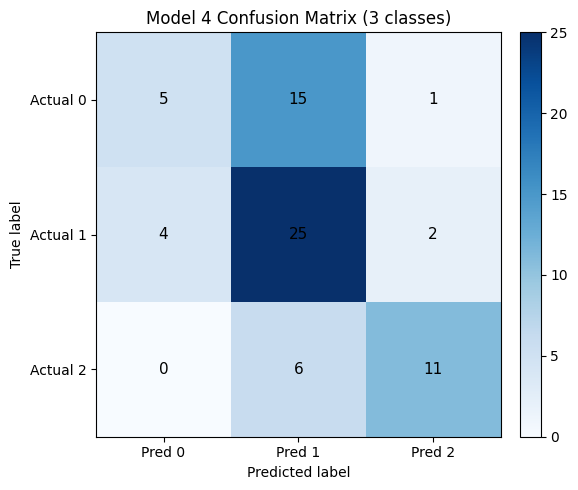

| label | true_sample_count | correctly_identified | recall |
| --- | --- | --- | --- |
| 0 | 21 | 5 | 0.238095 |
| 1 | 31 | 25 | 0.806452 |
| 2 | 17 | 11 | 0.647059 |

```
Per-class recall for Model 4:
  label 0: 5 / 21 correctly identified (recall = 0.2381)
  label 1: 25 / 31 correctly identified (recall = 0.8065)
  label 2: 11 / 17 correctly identified (recall = 0.6471)
```

```python
import numpy as np
import pandas as pd
import matplotlib.pyplot as plt
from sklearn.metrics import confusion_matrix

# Generate 3-class predictions on the held-out test set using the best Model 4 weights.
model_4_test_probs = model_4.predict([X_pre_test_bt, X_post_test_bt], verbose=0)
model_4_test_pred = np.argmax(model_4_test_probs, axis=1).astype(np.int32)

cm_model_4 = confusion_matrix(y_test_bt, model_4_test_pred, labels=[0, 1, 2])
cm_model_4_df = pd.DataFrame(
    cm_model_4,
    index=["Actual 0", "Actual 1", "Actual 2"],
    columns=["Pred 0", "Pred 1", "Pred 2"],
)

display(cm_model_4_df)

fig, ax = plt.subplots(figsize=(6, 5))
im = ax.imshow(cm_model_4, cmap="Blues")
plt.colorbar(im, ax=ax, fraction=0.046, pad=0.04)

ax.set_xticks([0, 1, 2])
ax.set_yticks([0, 1, 2])
ax.set_xticklabels(["Pred 0", "Pred 1", "Pred 2"])
ax.set_yticklabels(["Actual 0", "Actual 1", "Actual 2"])
ax.set_xlabel("Predicted label")
ax.set_ylabel("True label")
ax.set_title("Model 4 Confusion Matrix (3 classes)")

for i in range(cm_model_4.shape[0]):
    for j in range(cm_model_4.shape[1]):
        ax.text(j, i, cm_model_4[i, j], ha="center", va="center", color="black", fontsize=11)

plt.tight_layout()
plt.show()

# Per-class recall = among the true samples of each class, how many were correctly identified.
class_totals_model_4 = cm_model_4.sum(axis=1)
class_correct_model_4 = np.diag(cm_model_4)
class_recall_model_4 = np.divide(
    class_correct_model_4,
    class_totals_model_4,
    out=np.zeros_like(class_correct_model_4, dtype=float),
    where=class_totals_model_4 > 0,
)

per_class_diagnostics_df = pd.DataFrame({
    "true_sample_count": class_totals_model_4,
    "correctly_identified": class_correct_model_4,
    "recall": class_recall_model_4,
}, index=[0, 1, 2])
per_class_diagnostics_df.index.name = "label"
display(per_class_diagnostics_df)

print("Per-class recall for Model 4:")
for cls in [0, 1, 2]:
    row = per_class_diagnostics_df.loc[cls]
    print(
        f"  label {cls}: {int(row['correctly_identified'])} / {int(row['true_sample_count'])} correctly identified "
        f"(recall = {row['recall']:.4f})"
    )
```

#### 3.2.3 Model 4 as a Binary Damage Detector

|  | Pred no damage | Pred damage |
| --- | --- | --- |
| Actual no damage | 5 | 16 |
| Actual damage | 4 | 44 |

```
Model 4 binary accuracy (no damage vs damage): 0.7101
```

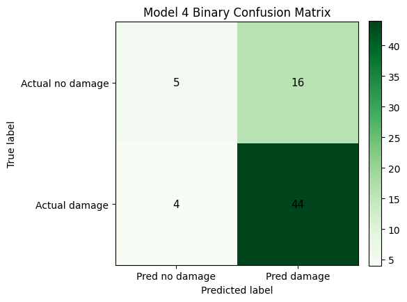

```python
from sklearn.metrics import accuracy_score

# Collapse the 3 local classes into a binary task: 0 = no damage, 1 = damage (original labels 1 and 2).
y_test_binary = np.where(y_test_bt == 0, 0, 1).astype(np.int32)
model_4_test_pred_binary = np.where(model_4_test_pred == 0, 0, 1).astype(np.int32)

binary_accuracy_model_4 = accuracy_score(y_test_binary, model_4_test_pred_binary)
binary_cm_model_4 = confusion_matrix(y_test_binary, model_4_test_pred_binary, labels=[0, 1])
binary_cm_model_4_df = pd.DataFrame(
    binary_cm_model_4,
    index=["Actual no damage", "Actual damage"],
    columns=["Pred no damage", "Pred damage"],
)

display(binary_cm_model_4_df)
print(f"Model 4 binary accuracy (no damage vs damage): {binary_accuracy_model_4:.4f}")

fig, ax = plt.subplots(figsize=(5.5, 4.5))
im = ax.imshow(binary_cm_model_4, cmap="Greens")
plt.colorbar(im, ax=ax, fraction=0.046, pad=0.04)

ax.set_xticks([0, 1])
ax.set_yticks([0, 1])
ax.set_xticklabels(["Pred no damage", "Pred damage"])
ax.set_yticklabels(["Actual no damage", "Actual damage"])
ax.set_xlabel("Predicted label")
ax.set_ylabel("True label")
ax.set_title("Model 4 Binary Confusion Matrix")

for i in range(binary_cm_model_4.shape[0]):
    for j in range(binary_cm_model_4.shape[1]):
        ax.text(j, i, binary_cm_model_4[i, j], ha="center", va="center", color="black", fontsize=11)

plt.tight_layout()
plt.show()
```

### 4. Full Area Prediction

```python
import numpy as np
import pandas as pd
import geopandas as gpd
import rasterio
from shapely.geometry import box

FULL_AREA_SHP_PATH = "/content/drive/MyDrive/data/osm_buildings_2022-clean.shp"
FULL_AREA_PRE_PATH = "/content/drive/MyDrive/data/pre-lan-full.tif"
FULL_AREA_POST_PATH = "/content/drive/MyDrive/data/post-lan-full.tif"
MODEL_4_WEIGHTS_PATH = "best_model_4_bitemporal_shared_encoder.weights.h5"
FULL_AREA_BATCH_SIZE = 32


def build_full_area_bitemporal_dataset(
    building_path,
    pre_path,
    post_path,
    buffer_pct=0.20,
    target_size=(128, 128),
):
    """Create pre/post chips for every building polygon in the full study area."""
    buildings_gdf = gpd.read_file(building_path).reset_index(drop=True)
    original_building_count = len(buildings_gdf)

    candidate_id_cols = ["osm_id", "osmid", "id", "fid", "FID", "OBJECTID"]
    polygon_id_col = next((col for col in candidate_id_cols if col in buildings_gdf.columns), None)

    with rasterio.open(pre_path) as pre_src, rasterio.open(post_path) as post_src:
        if pre_src.crs != post_src.crs:
            raise ValueError("Pre- and post-event rasters must use the same CRS.")

        buildings_gdf = buildings_gdf.to_crs(post_src.crs)

        # Keep only building polygons that overlap the post-image extent, and clip them to that extent.
        raster_extent_geom = box(*post_src.bounds)
        buildings_gdf = buildings_gdf[buildings_gdf.geometry.intersects(raster_extent_geom)].copy()
        buildings_gdf["geometry"] = buildings_gdf.geometry.intersection(raster_extent_geom)
        buildings_gdf = buildings_gdf[~buildings_gdf.geometry.is_empty].copy()
        buildings_gdf = buildings_gdf.reset_index(drop=True)

        metadata_records = []
        pre_chip_list = []
        post_chip_list = []

        for sample_idx, row in buildings_gdf.iterrows():
            square_bounds, side_raw, side_buffered = make_square_bounds(
                row.geometry,
                buffer_pct=buffer_pct,
            )

            pre_chip = crop_resize_rgb(pre_src, square_bounds, target_size=target_size)
            post_chip = crop_resize_rgb(post_src, square_bounds, target_size=target_size)

            pre_chip_list.append(pre_chip)
            post_chip_list.append(post_chip)

            polygon_id = row[polygon_id_col] if polygon_id_col is not None else sample_idx
            metadata_records.append({
                "sample_id": sample_idx,
                "polygon_id": polygon_id,
                "xmin": square_bounds[0],
                "ymin": square_bounds[1],
                "xmax": square_bounds[2],
                "ymax": square_bounds[3],
                "square_side_raw": side_raw,
                "square_side_buffered": side_buffered,
            })

    metadata_df = pd.DataFrame(metadata_records)
    pre_chips = np.asarray(pre_chip_list, dtype=np.uint8)
    post_chips = np.asarray(post_chip_list, dtype=np.uint8)
    return buildings_gdf, metadata_df, pre_chips, post_chips, original_building_count


# Build full-area bi-temporal chips using the same bbox + buffer + resize strategy as before.
full_area_gdf, full_area_metadata_df, full_area_pre_chips, full_area_post_chips, original_full_area_building_count = build_full_area_bitemporal_dataset(
    building_path=FULL_AREA_SHP_PATH,
    pre_path=FULL_AREA_PRE_PATH,
    post_path=FULL_AREA_POST_PATH,
    buffer_pct=BUFFER_PCT,
    target_size=TARGET_SIZE,
)

X_pre_full_area = full_area_pre_chips.astype("float32") / 255.0
X_post_full_area = full_area_post_chips.astype("float32") / 255.0

# Reload the best Model 4 weights before generating full-area predictions.
model_4.load_weights(MODEL_4_WEIGHTS_PATH)

full_area_probs = model_4.predict(
    [X_pre_full_area, X_post_full_area],
    batch_size=FULL_AREA_BATCH_SIZE,
    verbose=1,
)
full_area_pred = np.argmax(full_area_probs, axis=1).astype(np.int32)

# Join the predictions back to the building polygons.
full_area_pred_gdf = full_area_gdf.copy()
full_area_pred_gdf = full_area_pred_gdf.join(full_area_metadata_df)
full_area_pred_gdf["pred_label"] = full_area_pred
full_area_pred_gdf["pred_label_name"] = full_area_pred_gdf["pred_label"].map({
    0: "class 0",
    1: "class 1",
    2: "class 2",
})

pred_counts_full_area = pd.Series(full_area_pred).value_counts().reindex([0, 1, 2], fill_value=0)

print(f"Original building polygons in shapefile: {original_full_area_building_count}")
print(f"Building polygons kept inside tif extent: {len(full_area_pred_gdf)}")
print(f"Pre-event chips shape:  {full_area_pre_chips.shape}")
print(f"Post-event chips shape: {full_area_post_chips.shape}")
print("\nPredicted class counts across the full area:")
for cls, count in pred_counts_full_area.items():
    print(f"  class {cls}: {count}")

display(full_area_pred_gdf[["sample_id", "polygon_id", "pred_label", "pred_label_name"]].head())
```

```
72/72 ━━━━━━━━━━━━━━━━━━━━ 8s 107ms/step
Original building polygons in shapefile: 5725
Building polygons kept inside tif extent: 2298
Pre-event chips shape:  (2298, 128, 128, 3)
Post-event chips shape: (2298, 128, 128, 3)

Predicted class counts across the full area:
  class 0: 327
  class 1: 1320
  class 2: 651
```

|  | sample_id | polygon_id | pred_label | pred_label_name |
| --- | --- | --- | --- | --- |
| 0 | 0 | 165358378 | 1 | class 1 |
| 1 | 1 | 165358379 | 1 | class 1 |
| 2 | 2 | 165358495 | 1 | class 1 |
| 3 | 3 | 165381289 | 2 | class 2 |
| 4 | 4 | 166105571 | 1 | class 1 |

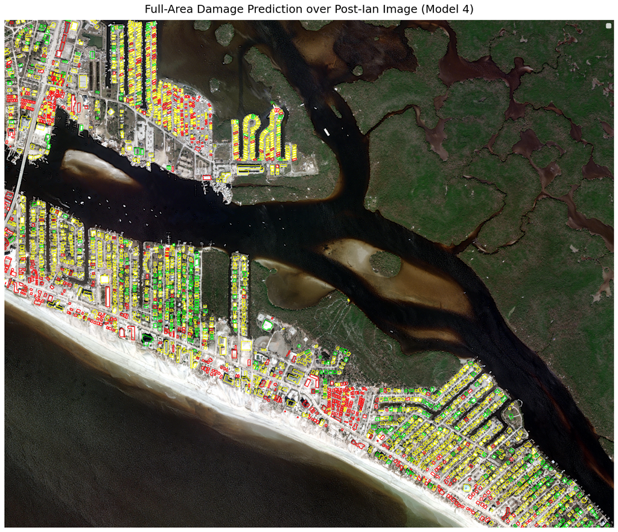

```python
import matplotlib.pyplot as plt

# Read the full post-event image and stretch it for cleaner map display.
full_post_img = read_rgb_tif(FULL_AREA_POST_PATH, bands=(1, 2, 3))
full_post_vis = percentile_stretch(full_post_img)

with rasterio.open(FULL_AREA_POST_PATH) as src:
    full_post_bounds = src.bounds

pred_class_colors = {
    0: "lime",
    1: "yellow",
    2: "red",
}

fig, ax = plt.subplots(figsize=(14, 14))
ax.imshow(
    full_post_vis,
    extent=[full_post_bounds.left, full_post_bounds.right, full_post_bounds.bottom, full_post_bounds.top],
    origin="upper",
)

for cls in [0, 1, 2]:
    subset = full_area_pred_gdf[full_area_pred_gdf["pred_label"] == cls]
    if len(subset) > 0:
        subset.plot(
            ax=ax,
            facecolor="none",
            edgecolor=pred_class_colors[cls],
            linewidth=1.0,
            label=f"Predicted class {cls}",
        )

ax.set_title("Full-Area Damage Prediction over Post-Ian Image (Model 4)", fontsize=18, pad=12)
ax.legend()
ax.set_axis_off()
plt.tight_layout()
plt.show()
```

### Discussion and Policy Implications

The bi-temporal model achieved the best overall performance in this study, although its improvement over the post-only fine-tuned model was relatively modest. This limited gap is likely related in part to the small size of the held-out test set (69). Nevertheless, the broader result is consistent and important: the two fine-tuned models (Models 3 and 4) performed substantially better than the two non-adapted baselines, demonstrating the effectiveness of the proposed approach. These findings suggest that a pretrained damage assessment model developed from data in other regions can be efficiently adapted to a local disaster context through transfer learning with a relatively small amount of manually labeled local data. From a practical perspective, this provides a realistic and scalable pipeline for smaller disaster-affected cities that may not have the resources to build a large training dataset from scratch, but still require rapid building-level damage assessment.